# Landmarking protocol

Jonathan Chang

# Introduction

You will be marking key points on images of fish, which will help determine the shape of different fishes and how that affects their performance in the water. Please continue reading for a short primer on fish anatomy, and a description of the points that you will need to mark on each photograph.

If you have questions, comments, or suggestions for improvement, contact Jonathan Chang via email: **jonathan dot chang at ucla dot edu**. This research is supported by the Encyclopedia of Life Rubenstein Fellowship and by NSF DEB-0918748.

**NOTE: You may not be asked to mark all of these points on a fish. Follow the instructions on the HIT page that you came from.**

# Fish anatomy

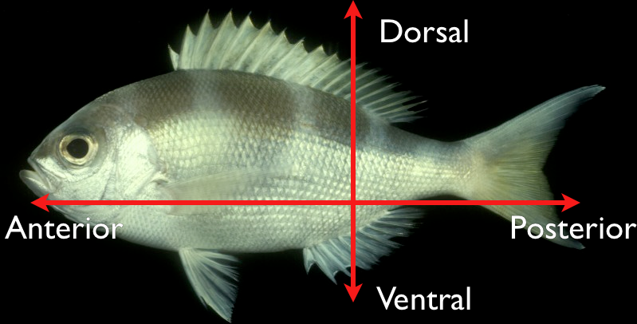

Anatomical directions

- Anterior: towards the mouth.
- Posterior: towards the tail.
- Dorsal: towards the top.
- Ventral: towards the bottom.
- Distal: the point furthest from the point of attachment to the body (for fins, etc)

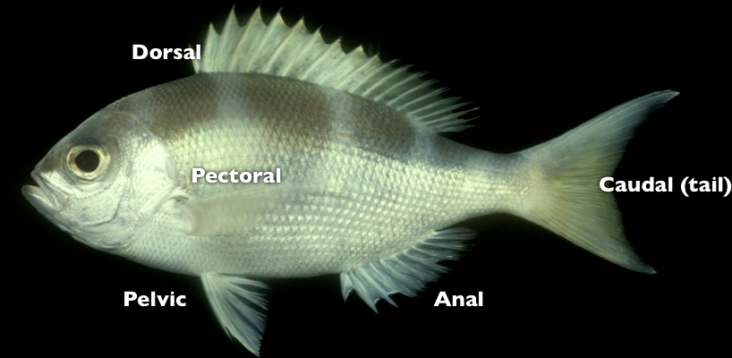

Fin rays are the soft spines that make up a fish's fins. They are clearly visible in the picture above on each of the labeled fins. Some fishes will have hard fin spines instead of soft fin rays. In these cases, you will landmark the fin spine instead of the fin ray.

# Tasks

## Mouth

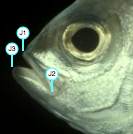

J1: The tip of the upper jaw.

J2: The intersection of the upper and lower jaw. This is not simply where the flesh of the upper and lower jaw meet!

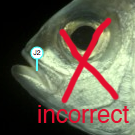

Instead, try to estimate the center of the intersection between the maxilla (mx) and the mandible (m), marked in the below image with a red "X":

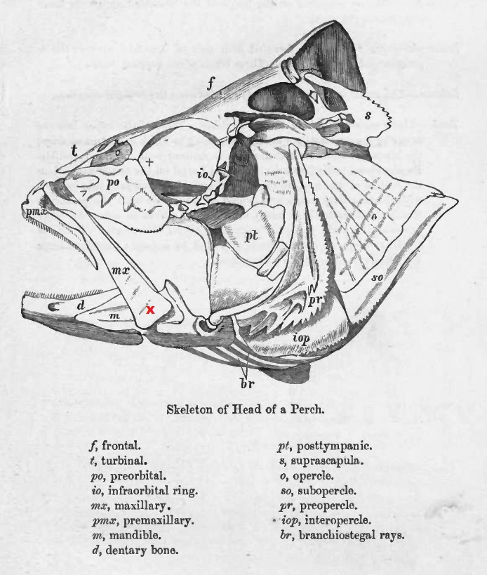

J3: The tip of the lower jaw.

## Eye

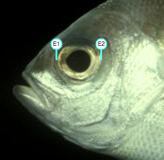

E1: The most anterior (forward) margin of the eye at its widest diameter.

E2: The most posterior (rearward) margin of the eye at its widest diameter.

## Operculum

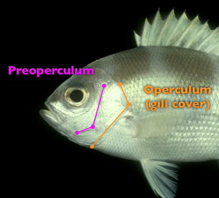

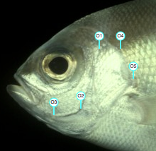

The preopercle points (O1-O3) might not be visible in certain fishes. Make your **best effort** to locate and mark these points. If you really can't find them place their points at the top-left corner of the image and make a comment in the comment box saying so.

O1: The top point of the preopercle.

O2: The posterior (rearward) "elbow" of the preopercle.

O3: The bottom point of the preopercle.

O4: The top point of the operculum (gill cover).

O5: The posterior (rearward) point of the operculum (gill cover).

## Pectoral fin

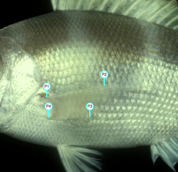

P1: Top intersection of pectoral fin rays with the base of the pectoral fin.

P2: The distal tip (farthest from body) of the pectoral fin's top fin ray.

P3: The distal tip (farthest from body) of the pectoral fin's bottom fin ray.

P4: Bottom intersection of pectoral fin rays with the base of the pectoral fin.

## Dorsal fin

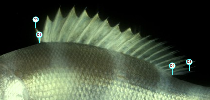

D1: Anterior (forward) intersection of the dorsal fin spine (or fin ray, if the spine is not present) with the body.

D2: The distal tip (farthest from body) of the dorsal fin's anterior fin spine (or fin ray, if the spine is not present).

D3: The distal tip (farthest from body) of the dorsal fin's posterior fin ray.

D4: Posterior (rearward) intersection of the dorsal fin rays with the body.

Common mistake: not marking the last fin ray correctly.

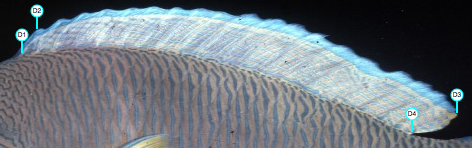

Correct version:

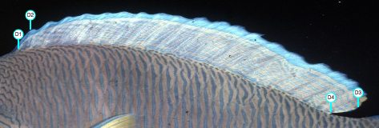

Common mistake: choosing the incorrect dorsal fin.

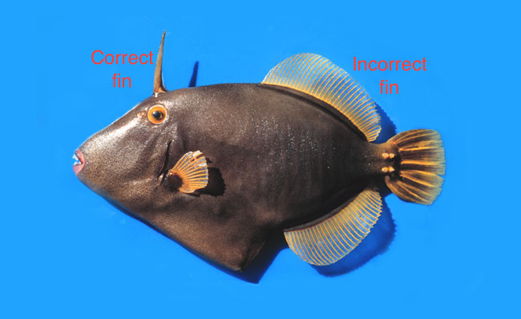

## Caudal fin

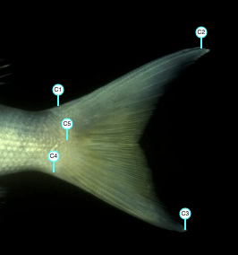

C1: Top intersection of the tail fin rays with the body.

C2: The distal tip (farthest from body) of the caudal fin's top principal fin ray.

C3: The distal tip (farthest from body) of the caudal fin's bottom principal fin ray.

C4: Bottom intersection of the tail fin rays with the body.

C5: The midpoint somewhere between C1 and C4 of the caudal fin's insertion on the body.

Always mark the *principal ray*, and ignore the procurrent ray. See below for a drawing of procurrent vs principal fin rays:

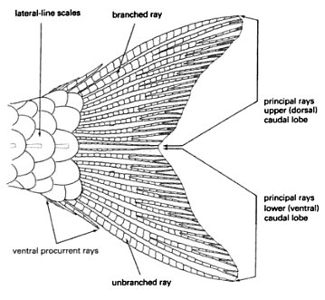

Common mistake: marking the procurrent fin ray instead of the principal fin ray.

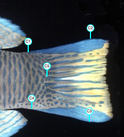

Correct version:

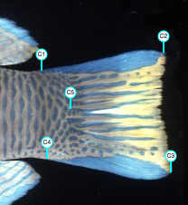

## Anal fin

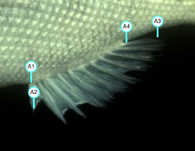

A1: Anterior (forward) intersection of the anal fin rays with the body.

A2: The distal tip (farthest from body) of the anal fin's anterior fin ray.

A3: The distal tip (farthest from body) of the anal fin's posterior fin ray.

A4: Posterior (rearward) intersection of the anal fin rays with the body.

Common mistake: not marking the last fin ray correctly.

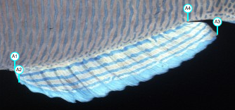

Correct version:

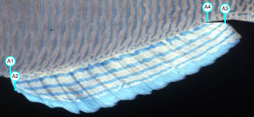

## Measurements

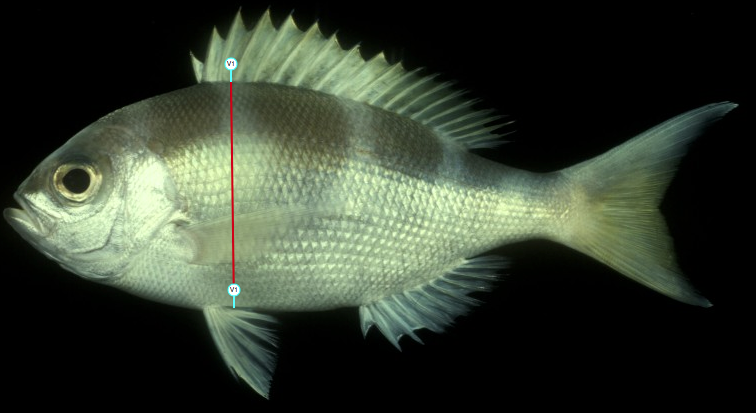

V1: The longest straight line that can be drawn through the body of the fish from top to bottom, excluding the fins.

# References

Fish skull image from: Day, Francis. *The Fauna of British India, Fishes*. London: Taylor and Francis, 1889.

Fish fin image from: Hodges, Elaine R. S. *The Guild Handbook of Scientific Illustration*. Hoboken, N.J.: John Wiley, 2003.